# CASA0005 Week 04 Homework：2010–2019 性别不平等指数变化

以 UNDP HDR 2025 的 GII 时间序列连接 Esri World Countries Generalized，比较 2010–2019 年性别不平等指数变化。差值定义为 **GII 2019 − GII 2010**；负值表示该指标下降，正值表示上升。

GII 范围为 0–1；差值是指数值之差，不是人数、百分比或百分点。任一年缺失或连接未匹配时保留 NA，不归为“无变化”。描述地图不用于识别政策因果效果。

项目为课程 `casa0005.Rproj`。普通 Knit 重新计算分析；文末 `render-report` 也可生成报告。安装、下载、导出和渲染块自身保持 `eval=FALSE`。

## 结果摘要

244 条地图边界记录中，154 条有完整两年差值：145 条 GII 下降、9 条上升；90 条缺失或未匹配。负差值表示该指标下降，不据此推断政策因果效果。

## 环境

### 依赖安装（缺包时）

依赖装入课程 `.local-review/R-library`；Mac 使用二进制包。

```r
helper_candidates <- c("tutorial-tools.R", "../tutorial-tools.R") # 兼容项目根目录与本周目录
helper_file <- helper_candidates[file.exists(helper_candidates)] # 只保留真实存在的工具文件
stopifnot(length(helper_file) >= 1L) # 没找到时停止，先确认打开了课程项目
source(helper_file[1]) # 共用检查函数
root <- gis_root() # 向上寻找含 casa0005.Rproj 的课程根目录
local_lib <- file.path(root, ".local-review", "R-library") # 课程内的包安装位置
dir.create(local_lib, recursive = TRUE, showWarnings = FALSE) # 需要时创建目录
.libPaths(c(local_lib, .libPaths())) # 先查本地库，再查已有系统库
required <- c("sf", "tidyverse", "tmap", "countrycode", "jsonlite", "ragg", "readxl", "rmarkdown", "knitr") # 本稿需要的包名向量
missing <- required[!vapply(required, requireNamespace, logical(1), quietly = TRUE)] # 仅找缺包
if (length(missing) > 0L) { # 没有缺包就不安装、不更新
  options(timeout = max(1200, getOption("timeout"))) # 给较大包足够的下载时间
  package_type <- if (Sys.info()[["sysname"]] == "Darwin") "binary" else getOption("pkgType")
  install.packages(missing, lib = local_lib, repos = "https://cloud.r-project.org", type = package_type)
}
```

### 包与项目路径

```r
helper_candidates <- c("tutorial-tools.R", "../tutorial-tools.R") # 两种支持的相对位置
helper_file <- helper_candidates[file.exists(helper_candidates)] # 找已有工具文件
stopifnot(length(helper_file) >= 1L) # 路径不对时先停止
source(helper_file[1]) # 共用检查函数
root <- gis_root() # 得到课程根目录，不写个人电脑的绝对路径
local_lib <- file.path(root, ".local-review", "R-library") # 找课程本地包库
if (dir.exists(local_lib)) .libPaths(c(local_lib, .libPaths())) # 重启 R 后重新识别本地包
gis_packages(c("sf", "tidyverse", "tmap", "countrycode", "jsonlite", "ragg", "readxl", "rmarkdown")) # 检查所需包可加载
stopifnot(utils::packageVersion("tmap") >= package_version("4.0.0")) # 本稿使用tmap4接口
stopifnot(utils::packageVersion("dplyr") >= package_version("1.1.1")) # relationship参数从1.1.1引入
library(sf) # 读入、检查和连接带 geometry 的矢量表
```

```r
library(tidyverse) # 提供 readr、dplyr、ggplot2 等数据处理函数
library(tmap) # 使用 tmap 4.x 的专题制图接口
getwd() # 查看当前工作目录，确认没有临时切到下载文件夹
```

```
## [1] "[project]/week04"
```

## 数据版本与下载路径

UNDP HDR 2025 完整时间序列包含 `gii_2010` 和 `gii_2019`；历史数值可能随版本修订。世界边界使用教程指定 Esri 图层的官方 FeatureServer GeoJSON 接口，未更换数据集。边界为概化版本，不视作两年各自的精确历史边界。

```r
raw_dir <- file.path(root, "data", "raw", "week04") # 原始输入只在本地保存
dir.create(raw_dir, recursive = TRUE, showWarnings = FALSE) # 没有目录时建立它
undp_url <- "https://hdr.undp.org/sites/default/files/2025_HDR/HDR25_Composite_indices_complete_time_series.csv" # 官方HDR25时间序列
metadata_url <- "https://hdr.undp.org/sites/default/files/2025_HDR/HDR25_Composite_indices_metadata.xlsx" # 同版本字段说明
world_layer_url <- paste0( # 拼接的是老师指定 Esri 图层的服务根路径
  "https://services.arcgis.com/P3ePLMYs2RVChkJx/arcgis/rest/services/", # Esri官方服务所在组织
  "World_Countries_(Generalized)/FeatureServer/0") # 老师链接的世界国家面图层
world_url <- paste0(world_layer_url, "/query?where=1%3D1&outFields=*&outSR=4326&f=geojson") # 全部字段与WGS84几何
world_count_url <- paste0(world_layer_url, "/query?where=1%3D1&returnCountOnly=true&f=json") # 同一图层的计数请求
undp_file <- file.path(raw_dir, "HDR25_Composite_indices_complete_time_series.csv") # 固定版本文件名
metadata_file <- file.path(raw_dir, "HDR25_Composite_indices_metadata.xlsx") # 保留变量定义
world_file <- file.path(raw_dir, "world-countries-generalized.geojson") # 地理边界文件
world_count_file <- file.path(raw_dir, "world-countries-count.json") # 同批下载的预期要素数
file.exists(c(undp_file, metadata_file, world_file, world_count_file)) # 查看哪些输入已经存在
```

```
## [1] TRUE TRUE TRUE TRUE
```

### 下载与格式验证

保留原输入，临时文件通过 CSV 表头、XLSX 容器或 GeoJSON 结构验证后才复制到正式位置。UNDP 下载请求带普通 User-Agent 与官方 Referer；遇 403 可从官方下载页保存相同完整时间序列与元数据，不以单年 Table 5 代替。

```r
options(timeout = max(1200, getOption("timeout"))) # 允许慢速网络下载较大边界
undp_headers <- c( # 按正常官方网页下载请求提供信息，不包含密码或 token
  "User-Agent" = "Mozilla/5.0", # 普通浏览器类型标识
  "Referer" = "https://hdr.undp.org/data-center/documentation-and-downloads") # 表示从官方下载页进入
valid_hdr_csv <- function(path) { # 下载后只检查 CSV 表头，不计算作业结果
  header <- readr::read_lines(path, n_max = 1, locale = readr::locale(encoding = "Windows-1252")) # 只读首行表头
  fields <- strsplit(header, ",", fixed = TRUE)[[1]] # 按逗号拆出表头字段
  all(c("iso3", "country", "gii_2010", "gii_2019") %in% fields) # 需要四个指定字段
}
valid_world_json <- function(path) { # 验证文件真的是完整 GeoJSON，要素不为空
  x <- jsonlite::read_json(path, simplifyVector = FALSE) # 读取文件结构，不执行地理分析
  identical(x$type, "FeatureCollection") && length(x$features) > 0L && # 类型正确且有要素
    !isTRUE(x$exceededTransferLimit) # 服务明确截断时不能继续
}
valid_count_json <- function(path) { # 验证只有计数的服务响应
  x <- jsonlite::read_json(path, simplifyVector = TRUE) # 将简单JSON数值转成R向量
  is.null(x$error) && length(x$count) == 1L && is.finite(x$count) && x$count > 0 # 计数有效且无服务错误
}
valid_xlsx <- function(path) { # xlsx 的容器是 ZIP，前两个字节应为 PK
  identical(readBin(path, what = "raw", n = 2L), charToRaw("PK")) # 比较ZIP容器签名
}
download_once <- function(url, destination, validator, headers = NULL) {
  if (file.exists(destination)) { # 已有输入不重写，也不悄悄换版本
    stopifnot(isTRUE(validator(destination))) # 已有文件仍需通过格式检查
    message("沿用已有输入：", basename(destination))
    return(invisible(destination)) # 返回现有路径，跳过网络请求
  }
  temporary <- tempfile(pattern = "download-", tmpdir = dirname(destination)) # 先写临时文件
  on.exit(unlink(temporary), add = TRUE) # 成功或失败后只清理本函数临时文件
  status <- utils::download.file(url, temporary, method = "libcurl", mode = "wb", headers = headers) # 先下载到临时路径
  stopifnot(status == 0L, file.exists(temporary), isTRUE(validator(temporary))) # 验证内容后才保留
  stopifnot(file.copy(temporary, destination, overwrite = FALSE)) # 成功后复制成目标文件，不覆盖原件
  invisible(destination) # 不把整个数据内容打印到 Console
}
download_once(undp_url, undp_file, valid_hdr_csv, headers = undp_headers) # 下载时间序列
download_once(metadata_url, metadata_file, valid_xlsx, headers = undp_headers) # 下载数据字典
download_once(world_count_url, world_count_file, valid_count_json) # 先保存边界计数
download_once(world_url, world_file, valid_world_json) # 保存同一个服务的边界 GeoJSON
file.info(c(undp_file, metadata_file, world_file))[, c("size", "mtime")] # 核对大小与本地保存时间
```

### 输入完整性记录

GeoJSON 要素数与同批服务计数一致，拒绝截断响应；清单保留 URL、字节数、本地时间和 MD5。

```r
required_files <- c(undp_file, metadata_file, world_file, world_count_file) # 分析输入与变量定义
stopifnot(all(file.exists(required_files))) # 缺少任一输入时先返回下载步骤
first_line <- readr::read_lines(undp_file, n_max = 1, locale = readr::locale(encoding = "Windows-1252"))
stopifnot(all(c("iso3", "country", "gii_2010", "gii_2019") %in% strsplit(first_line, ",", fixed = TRUE)[[1]]))
world_document <- jsonlite::read_json(world_file, simplifyVector = FALSE) # 保留 GeoJSON 的结构列表
expected_count <- jsonlite::read_json(world_count_file, simplifyVector = TRUE)$count # 读取同批计数
stopifnot(identical(world_document$type, "FeatureCollection")) # 确认不是服务错误对象
stopifnot(!isTRUE(world_document$exceededTransferLimit)) # 明确不接受被截断的响应
stopifnot(length(world_document$features) == expected_count) # 边界要素数必须与计数一致
input_manifest <- tibble( # 留下来源、文件和校验信息，便于以后重现
  file = basename(required_files), url = c(undp_url, metadata_url, world_url, world_count_url), # 文件与来源一一对应
  bytes = file.info(required_files)$size, # 字节数有助于发现空文件或不完整下载
  local_saved_time = format(file.info(required_files)$mtime, tz = "Europe/London", usetz = TRUE), # 本地文件保存时间
  md5 = unname(tools::md5sum(required_files))) # 内容摘要去掉多余的命名属性
input_manifest # 查看实际下载得到的文件信息，不预填数值
```

```
## # A tibble: 4 × 5
##   file                                       url    bytes local_saved_time md5
##   <chr>                                      <chr>  <dbl> <chr>            <chr>
## 1 HDR25_Composite_indices_complete_time_ser… http… 2.00e6 2026-11-01 18:2… 4026…
## 2 HDR25_Composite_indices_metadata.xlsx      http… 1.37e4 2026-11-01 18:2… e63b…
## 3 world-countries-generalized.geojson        http… 8.74e6 2026-11-01 18:2… 5335…
## 4 world-countries-count.json                 http… 1.3 e1 2026-11-01 18:2… 14df…
```

## 元数据与 GII 字段

`gii` 是指数，`gii_rank` 是排名。建议引文位于元数据的 `recommended_citation` 表；CSV 版本使用 Windows-1252。

```r
readxl::excel_sheets(metadata_file) # 列出元数据的工作表
```

```
## [1] "codebook"             "recommended_citation"
```

```r
codebook <- readxl::read_excel(metadata_file, sheet = "codebook") # 读取变量说明表
gis_columns(codebook, c("Full name", "Short name", "Time series")) # 检查说明表结构
codebook %>% filter(stringr::str_detect(as.character(`Short name`), "^gii(_rank)?$")) # 定位GII与排名
```

```
## # A tibble: 2 × 3
##   `Full name`                     `Short name` `Time series`
##   <chr>                           <chr>        <chr>
## 1 GII Rank                        gii_rank     2023
## 2 Gender Inequality Index (value) gii          1990-2023
```

### 完整时间序列

所有字段先按文字读取，随后显式转换两年指数；缺失标记不包含数值 0。

```r
hdr_raw <- readr::read_csv( # 读完整时间序列，先将全部字段作为文字保留
  undp_file, locale = readr::locale(encoding = "Windows-1252"), # 指定核验过的原文件编码
  col_types = readr::cols(.default = readr::col_character()), # 暂不让readr自动猜列类型
  na = c("", "NA", "N/A", "n/a", ".."), trim_ws = TRUE) # 识别缺失标识并去外围空格
names(hdr_raw) <- tolower(gsub("[^A-Za-z0-9]+", "_", names(hdr_raw))) # 统一字段名
gis_columns(hdr_raw, c("iso3", "country", "gii_2010", "gii_2019")) # 只接受所需列存在的版本
readr::problems(hdr_raw) # 检查读取问题，不因 show_col_types 消息而忽视错误
```

```
## # A tibble: 0 × 5
## # ℹ 5 variables: row <int>, col <int>, expected <chr>, actual <chr>, file <chr>
```

```r
dim(hdr_raw)
```

```
## [1]  206 1112
```

```r
hdr_raw %>% dplyr::select(iso3, country, gii_2010, gii_2019) %>% head(10) # 先看必要四列
```

```
## # A tibble: 10 × 4
##    iso3  country             gii_2010 gii_2019
##    <chr> <chr>               <chr>    <chr>
##  1 AFG   Afghanistan         0.704    0.676
##  2 ALB   Albania             0.192    0.131
##  3 DZA   Algeria             0.508    0.385
##  4 AND   Andorra             <NA>     <NA>
##  5 AGO   Angola              0.556    0.536
##  6 ATG   Antigua and Barbuda <NA>     <NA>
##  7 ARG   Argentina           0.37     0.283
##  8 ARM   Armenia             0.352    0.216
##  9 AUS   Australia           0.137    0.079
## 10 AUT   Austria             0.105    0.052
```

## 国家／地区记录

以代码字典排除世界、区域和发展水平汇总行，并保留排除清单。字典分类沿用数据来源，不作为主权认定；真正国家／地区的异常代码需显式核对，不任意删除。

```r
hdr_codes <- hdr_raw %>% mutate(iso3 = stringr::str_to_upper(stringr::str_trim(iso3))) # 统一代码
valid_iso3 <- unique(na.omit(countrycode::codelist$iso3c)) # 从 countrycode 的代码表取得合法 ISO3
hdr_codes <- hdr_codes %>% mutate(is_country = !is.na(iso3) & iso3 %in% valid_iso3) # 明确国家/地区资格
excluded_aggregates <- hdr_codes %>% filter(!is_country) %>% dplyr::select(iso3, country) # 保留排除清单
excluded_aggregates # 逐项检查排除的是汇总/非 ISO 行，不能静默丢弃
```

```
## # A tibble: 11 × 2
##    iso3      country
##    <chr>     <chr>
##  1 ZZA.VHHD  Very high human development
##  2 ZZB.HHD   High human development
##  3 ZZC.MHD   Medium human development
##  4 ZZD.LHD   Low human development
##  5 ZZE.AS    Arab States
##  6 ZZF.EAP   East Asia and the Pacific
##  7 ZZG.ECA   Europe and Central Asia
##  8 ZZH.LAC   Latin America and the Caribbean
##  9 ZZI.SA    South Asia
## 10 ZZJ.SSA   Sub-Saharan Africa
## 11 ZZK.WORLD World
```

```r
gii_text <- hdr_codes %>% filter(is_country) %>% dplyr::select(iso3, undp_name = country, gii_2010, gii_2019) # 仅留国家及两年指数
gis_unique(gii_text, "iso3") # 同一个国家/地区只能有一行；发现重复时停止，不用任意去重
```

### 数值与范围

两年指数逐列转换，非缺失字符串转换失败时停止；有效值限定 0–1，代码保持文字。

```r
gii <- gii_text %>% mutate( # 只转换两个指数列，地区代码仍是文字
  gii_2010 = readr::parse_double(gii_2010, na = c("", "NA", "..")), # 2010字符串转小数
  gii_2019 = readr::parse_double(gii_2019, na = c("", "NA", ".."))) # 同法转换2019，保留缺失
conversion_failures <- gii_text %>% filter( # 检查非缺失原字符串是否被转换成 NA
  (!is.na(gii_2010) & is.na(gii$gii_2010)) | (!is.na(gii_2019) & is.na(gii$gii_2019)))
conversion_failures # 非空时先查字符串与数据字典，不进行下游计算
```

```
## # A tibble: 0 × 4
## # ℹ 4 variables: iso3 <chr>, undp_name <chr>, gii_2010 <chr>, gii_2019 <chr>
```

```r
stopifnot(nrow(conversion_failures) == 0L) # 不把无法解析的文字悄悄当缺失
stopifnot(all(is.na(gii$gii_2010) | dplyr::between(gii$gii_2010, 0, 1))) # 检查2010指数范围
stopifnot(all(is.na(gii$gii_2019) | dplyr::between(gii$gii_2019, 0, 1))) # 检查2019指数范围
gis_unique(gii, "iso3") # 转换数值后再确认键未改变
summary(gii[c("gii_2010", "gii_2019")]) # 查看分布、范围及缺失数
```

```
##     gii_2010         gii_2019
##  Min.   :0.0480   Min.   :0.0140
##  1st Qu.:0.2085   1st Qu.:0.1640
##  Median :0.4080   Median :0.3620
##  Mean   :0.3872   Mean   :0.3446
##  3rd Qu.:0.5450   3rd Qu.:0.5010
##  Max.   :0.7670   Max.   :0.8160
##  NAs    :41       NAs    :26
```

## 世界边界与 ISO 转换

Esri `ISO` 为 ISO2，转换到 UNDP 的 ISO3。`COUNTRYAFF` 和 `AFF_ISO` 是所属国字段，不用于把所属国 GII 复制到领土。未识别代码单独保留。

```r
world_raw <- sf::st_read(world_file, quiet = TRUE) # 读取已验证的 GeoJSON
names(world_raw) # 看真实字段名，不猜连接键
```

```
## [1] "FID"           "COUNTRY"       "ISO"           "COUNTRYAFF"
## [5] "AFF_ISO"       "Shape__Area"   "Shape__Length" "geometry"
```

```r
gis_columns(world_raw, c("FID", "COUNTRY", "ISO", "COUNTRYAFF", "AFF_ISO")) # 检查该图层结构
stopifnot(nrow(world_raw) == expected_count) # 与同批服务计数再核对一次
stopifnot(!is.na(sf::st_crs(world_raw))) # 缺 CRS 时不能凭外观补标签
world_raw <- sf::st_transform(world_raw, 4326) # 统一为请求所定义的 WGS84，经纬度单位为度
world_raw <- sf::st_make_valid(world_raw) # 修复几何结构，原始文件仍保留不改
world_raw <- world_raw %>% mutate( # Esri 的 ISO 是两字符代码，UNDP 使用三字符代码
  iso2 = stringr::str_to_upper(stringr::str_trim(as.character(ISO))), # 先清理边界两位代码
  iso3 = countrycode::countrycode(iso2, origin = "iso2c", destination = "iso3c", warn = FALSE)) # 用字典转三位代码
unmapped_boundary_codes <- world_raw %>% filter(is.na(iso3)) %>% sf::st_drop_geometry() %>%
  dplyr::select(FID, COUNTRY, ISO, COUNTRYAFF, AFF_ISO) # 保留无法转换的边界清单
unmapped_boundary_codes # 无法映射的地区暂时保留，后面以灰色显示
```

```
## [1] FID        COUNTRY    ISO        COUNTRYAFF AFF_ISO
## <0 rows> (or 0-length row.names)
```

### 多部件几何与唯一键

同 ISO3 的地理部分通过 sf union 合为一行，保留来源名称与部分数。未知代码各自使用临时键，不把所有 NA 合成同一个国家。

```r
boundary_parts <- world_raw %>% sf::st_drop_geometry() %>% filter(!is.na(iso3)) %>%
  count(iso3, name = "parts") %>% filter(parts > 1L) # 先公开哪些代码有多个部分
boundary_parts # 查看需要合并的多部件国家/地区
```

```
##   iso3 parts
## 1  ATF     3
## 2  BES     3
## 3  ESP     2
## 4  PRT     3
```

```r
world_known <- world_raw %>% filter(!is.na(iso3)) %>% group_by(iso3) %>%
  summarise(world_name = paste(sort(unique(COUNTRY)), collapse = " / "),
            source_parts = n(), do_union = TRUE, .groups = "drop") %>%
  mutate(join_key = iso3) # sf summarise 对同一代码的几何求并集，保留一个连接键
world_unknown <- world_raw %>% filter(is.na(iso3)) %>% transmute( # 不把全部未知代码合成一个国家
  iso3 = NA_character_, world_name = COUNTRY, source_parts = 1L,
  join_key = paste0("unmatched_boundary_", FID)) # 每个未知边界使用独立临时键
world <- bind_rows(world_known, world_unknown) # 合并已识别和未识别边界
gis_unique(world, "join_key") # 所有地图记录的连接键必须唯一，且没有 NA
stopifnot(all(sf::st_is_valid(world))) # 连接前再检查几何有效性
```

## 一对一左连接

双向列出未匹配记录，保留所有边界。覆盖差异与缺失不通过猜代码、复制所属国数值或任意删区消除。

```r
world_table <- sf::st_drop_geometry(world) # anti_join 只比较普通属性，不进行空间叠置
no_gii_for_boundary <- dplyr::anti_join(world_table, gii, by = c("join_key" = "iso3"))
no_boundary_for_gii <- dplyr::anti_join(gii, world_table, by = c("iso3" = "join_key"))
no_gii_for_boundary %>% dplyr::select(world_name, iso3, join_key) # 哪些边界没有统计行
```

```
## # A tibble: 50 × 3
##    world_name                                                     iso3  join_key
##    <chr>                                                          <chr> <chr>
##  1 Aruba                                                          ABW   ABW
##  2 Anguilla                                                       AIA   AIA
##  3 American Samoa                                                 ASM   ASM
##  4 Antarctica                                                     ATA   ATA
##  5 French Southern Territories / Glorioso Islands / Juan De Nova… ATF   ATF
##  6 Bonaire / Saba / Saint Eustatius                               BES   BES
##  7 Saint Barthelemy                                               BLM   BLM
##  8 Bermuda                                                        BMU   BMU
##  9 Bouvet Island                                                  BVT   BVT
## 10 Cocos Islands                                                  CCK   CCK
## # ℹ 40 more rows
```

```r
no_boundary_for_gii %>% dplyr::select(iso3, undp_name) # 哪些统计国家/地区没有边界
```

```
## # A tibble: 1 × 2
##   iso3  undp_name
##   <chr> <chr>
## 1 HKG   Hong Kong, China (SAR)
```

```r
world_gii <- dplyr::left_join( # 保留全部地图范围，而不是悄悄丢掉没有GII的边界
  world, gii, by = c("join_key" = "iso3"), relationship = "one-to-one") # 明确双方键与一对一关系
stopifnot(nrow(world_gii) == nrow(world)) # 连接不能意外增加或减少地图行数
gis_unique(world_gii, "join_key") # 确认一国/地区一行的结构仍成立
world_gii %>% sf::st_drop_geometry() %>%
  dplyr::select(world_name, undp_name, iso3, gii_2010, gii_2019) %>% head(10) # 抽查字段
```

```
## # A tibble: 10 × 5
##    world_name           undp_name            iso3  gii_2010 gii_2019
##    <chr>                <chr>                <chr>    <dbl>    <dbl>
##  1 Aruba                <NA>                 ABW     NA       NA
##  2 Afghanistan          Afghanistan          AFG      0.704    0.676
##  3 Angola               Angola               AGO      0.556    0.536
##  4 Anguilla             <NA>                 AIA     NA       NA
##  5 Albania              Albania              ALB      0.192    0.131
##  6 Andorra              Andorra              AND     NA       NA
##  7 United Arab Emirates United Arab Emirates ARE      0.165    0.039
##  8 Argentina            Argentina            ARG      0.37     0.283
##  9 Armenia              Armenia              ARM      0.352    0.216
## 10 American Samoa       <NA>                 ASM     NA       NA
```

## 2010–2019 变化

计算 `gii_change = gii_2019 - gii_2010`；完整配对和缺失分别记录，NA 不归入 No change。

```r
world_gii <- world_gii %>% mutate( # 所有结果都来自刚才按代码连接的两列
  gii_change = gii_2019 - gii_2010, # 正数上升，负数下降；NA自然继续为NA
  change_group = case_when( # 用文字分类帮助解释，不改变连续差值
    is.na(gii_change) ~ "Missing one/both years",
    gii_change < 0 ~ "GII decreased",
    gii_change > 0 ~ "GII increased",
    TRUE ~ "No change"))
coverage <- world_gii %>% sf::st_drop_geometry() %>% summarise(
  map_rows = n(), complete_pairs = sum(!is.na(gii_change)), missing_pairs = sum(is.na(gii_change)))
coverage # 统计的是地图国家/地区记录数，不是人口数
```

```
## # A tibble: 1 × 3
##   map_rows complete_pairs missing_pairs
##      <int>          <int>         <int>
## 1      244            154            90
```

```r
world_gii %>% sf::st_drop_geometry() %>% count(change_group) # 查看每类实际有多少地区
```

```
## # A tibble: 3 × 2
##   change_group               n
##   <chr>                  <int>
## 1 GII decreased            145
## 2 GII increased              9
## 3 Missing one/both years    90
```

```r
stopifnot(coverage$complete_pairs > 0L) # 两年都有效的记录必须至少有一条
stopifnot(all(is.na(world_gii$gii_change) | dplyr::between(world_gii$gii_change, -1, 1)))
```

## 零中心差值地图

负差值蓝色、正差值红色，色标以零对称；缺失为灰色。颜色表示指数变化，不表示人口数量。

```r
tmap::tmap_mode("plot") # 先用静态模式，便于报告与PNG一致
```

```
## ℹ tmap modes "plot" - "view"
## ℹ toggle with `tmap::ttm()`
```

```r
limit <- max(abs(world_gii$gii_change), na.rm = TRUE) # 找两侧差值的共同绝对范围
if (!is.finite(limit) || limit == 0) limit <- 0.01 # 全部恰好为0时仍能建立图例
gii_change_map <- tmap::tm_shape(world_gii) +
  tmap::tm_polygons( # 图中填色用连续差值，不用GII水平或排名
    fill = "gii_change", col = "grey40", lwd = 0.25,
    fill.scale = tmap::tm_scale_continuous(
      limits = c(-limit, limit), midpoint = 0, # 两侧同范围，0为中心
      values = c("#2166ac", "#f7f7f7", "#b2182b"), # 负值蓝、0近白、正值红
      value.na = "grey80", label.na = "Missing 2010 or 2019 / unmatched"), # 灰色单独解释缺失
    fill.legend = tmap::tm_legend(title = "GII 2019 − GII 2010")) + # 图例明确相减方向
  tmap::tm_title("Change in Gender Inequality Index, 2010–2019") + # 为图添加时间与指标标题
  tmap::tm_credits("UNDP HDR 2025; World Countries Generalized: Esri and sources") # 写数据来源
gii_change_map # 显示地图；先核对图例方向，再写个人观察
```

```
## [tip] Consider a suitable map projection, e.g. by adding `+ tm_crs("auto")`.
## [plot mode] fit legend/component: Some legend items or map compoments do not
## fit well, and are therefore rescaled.
## ℹ Set the tmap option `component.autoscale = FALSE` to disable rescaling.
```

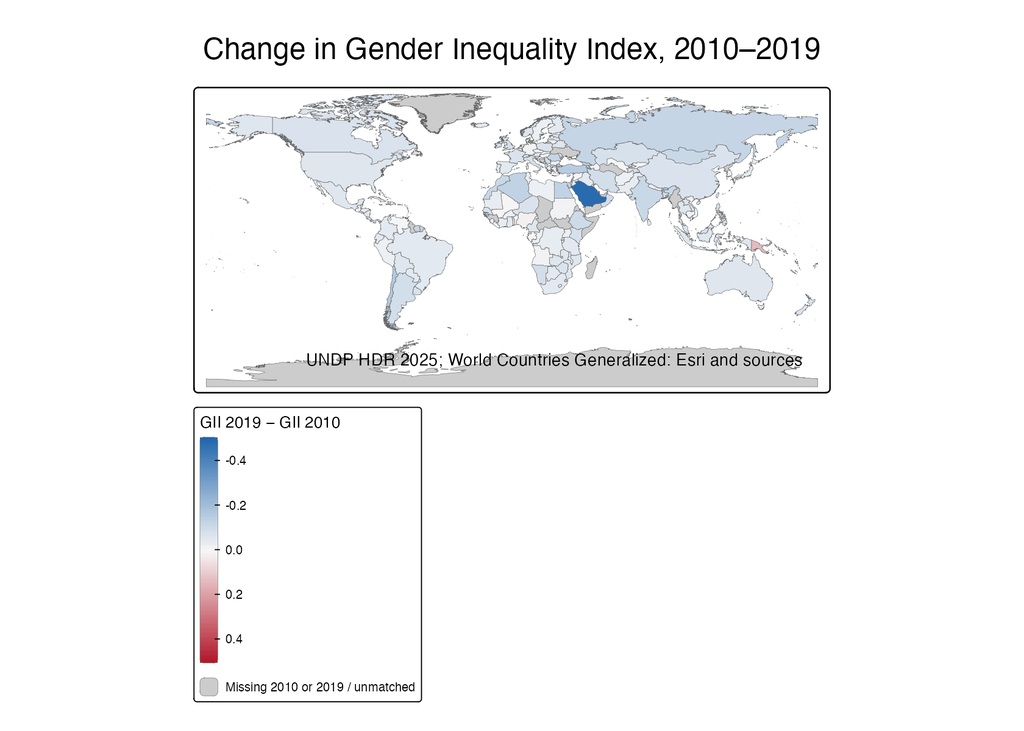

### 表格与分布核对

按两个方向排序对照图色；直方图观测单位为完整配对的地图国家／地区，不是人口，也非人口加权全球结果。

```r
matched_complete <- world_gii %>% sf::st_drop_geometry() %>% filter(!is.na(gii_change))
matched_complete %>% dplyr::select(iso3, world_name, gii_2010, gii_2019, gii_change) %>%
  arrange(gii_change) %>% slice_head(n = 10) # GII 差值升序核对
```

```
## # A tibble: 10 × 5
##    iso3  world_name           gii_2010 gii_2019 gii_change
##    <chr> <chr>                   <dbl>    <dbl>      <dbl>
##  1 QAT   Qatar                   0.663    0.162     -0.501
##  2 SAU   Saudi Arabia            0.754    0.283     -0.471
##  3 TON   Tonga                   0.767    0.45      -0.317
##  4 BTN   Bhutan                  0.442    0.265     -0.177
##  5 CHL   Chile                   0.35     0.195     -0.155
##  6 TUR   Turkiye                 0.411    0.27      -0.141
##  7 ARM   Armenia                 0.352    0.216     -0.136
##  8 GEO   Georgia                 0.43     0.296     -0.134
##  9 EGY   Egypt                   0.552    0.424     -0.128
## 10 ARE   United Arab Emirates    0.165    0.039     -0.126
```

```r
matched_complete %>% dplyr::select(iso3, world_name, gii_2010, gii_2019, gii_change) %>%
  arrange(desc(gii_change)) %>% slice_head(n = 10) # 查看相反方向，不预先声称哪些国家会出现
```

```
## # A tibble: 10 × 5
##    iso3  world_name       gii_2010 gii_2019 gii_change
##    <chr> <chr>               <dbl>    <dbl>      <dbl>
##  1 VUT   Vanuatu             0.536    0.797    0.261
##  2 PNG   Papua New Guinea    0.682    0.816    0.134
##  3 BLZ   Belize              0.406    0.461    0.055
##  4 CYP   Cyprus              0.191    0.235    0.044
##  5 NGA   Nigeria             0.67     0.69     0.0200
##  6 HTI   Haiti               0.613    0.625    0.0120
##  7 LBR   Liberia             0.644    0.65     0.00600
##  8 MLI   Mali                0.666    0.671    0.00500
##  9 GAB   Gabon               0.523    0.527    0.00400
## 10 BEN   Benin               0.637    0.636   -0.00100
```

```r
summary(matched_complete$gii_change)
```

```
##     Min.  1st Qu.   Median     Mean  3rd Qu.     Max.
## -0.50100 -0.07000 -0.04850 -0.05601 -0.02825  0.26100
```

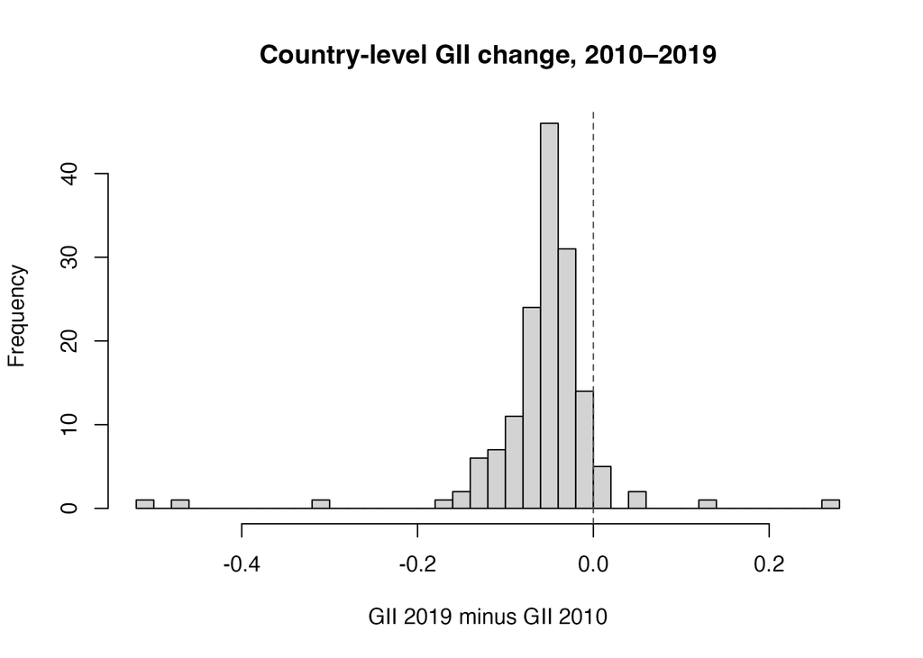

```r
hist(matched_complete$gii_change, breaks = "FD", # 用数据决定分箱，而不是预填结果
     main = "Country-level GII change, 2010–2019", xlab = "GII 2019 minus GII 2010")
abline(v = 0, lty = 2, col = "grey30") # 在直方图上画出0参考线
```

## 可选导出

使用真实时间戳和同名保护，CSV 保存属性、GPKG 保存空间结果、PNG 保存样式。tmap 样式不随普通 GPKG 写入；PNG 使用 ragg。

```r
run_tag <- format(Sys.time(), "%Y%m%d-%H%M%S", tz = "Europe/London") # 记录真实本次时间
output_dir <- file.path(root, "week04", "outputs") # 数据结果默认留在本地
figure_dir <- file.path(root, "week04", "figures") # 经过检查的派生图片可纳入仓库
dir.create(output_dir, recursive = TRUE, showWarnings = FALSE) # 需要时建输出目录
dir.create(figure_dir, recursive = TRUE, showWarnings = FALSE) # 需要时建图片目录
csv_target <- file.path(output_dir, paste0("gii-change-2010-2019-", run_tag, ".csv"))
gpkg_target <- file.path(output_dir, paste0("gii-change-2010-2019-", run_tag, ".gpkg"))
png_target <- file.path(figure_dir, paste0("gii-change-2010-2019-", run_tag, ".png"))
manifest_target <- file.path(output_dir, paste0("input-manifest-", run_tag, ".csv"))
stopifnot(!any(file.exists(c(csv_target, gpkg_target, png_target, manifest_target)))) # 禁止覆盖
readr::write_csv(sf::st_drop_geometry(world_gii), csv_target, na = "NA") # 保存实际连接与差值表
sf::st_write(world_gii, gpkg_target, layer = "gii_change", quiet = TRUE) # 保存空间结果
tmap::tmap_save(gii_change_map, png_target, device = ragg::agg_png, # 避开这台Mac缺失的Cairo/X11
                width = 12, height = 7, units = "in", dpi = 200)
readr::write_csv(input_manifest, manifest_target) # 保存本次输入摘要
stopifnot(all(file.exists(c(csv_target, gpkg_target, png_target, manifest_target)))) # 真正检查文件存在
c(csv_target, gpkg_target, png_target, manifest_target) # 打印文件位置，便于打开查看
```

## HTML 报告

从新 R 会话运行此独立渲染块，`execute=TRUE` 重建普通分析；下载、安装和导出不会自动运行。生成的时间戳 HTML 保留旧报告。

```r
report_helpers <- c("tutorial-tools.R", "../tutorial-tools.R") # Restart R后也能从支持的目录找到工具
report_helper <- report_helpers[file.exists(report_helpers)] # 仅保留真实工具文件
stopifnot(length(report_helper) >= 1L) # 找不到时先打开课程Rproj
source(report_helper[1]) # 恢复路径检查函数，不依赖上次会话对象
report_root <- gis_root() # 从Rproj确定课程根目录
report_lib <- file.path(report_root, ".local-review", "R-library") # 定位本课程本地包库
if (dir.exists(report_lib)) .libPaths(c(report_lib, .libPaths())) # 让新会话识别本地rmarkdown等包
gis_packages("rmarkdown") # 缺包时先执行安装块
report_input <- file.path(report_root, "week04", "homework.Rmd") # 明确只渲染第四周，不误选其他周同名文件
report_input <- normalizePath(report_input, mustWork = TRUE) # 校验该文件确实存在
report_name <- paste0("homework-report-", format(Sys.time(), "%Y%m%d-%H%M%S"), ".html")
report_target <- file.path(dirname(report_input), report_name) # HTML放本周目录，便于审阅后分享
stopifnot(!file.exists(report_target)) # 不覆盖已经保存的报告
rmarkdown::render(input = report_input, output_file = report_name, # 从文档中的输入重新计算
                  output_dir = dirname(report_input), params = list(execute = TRUE), # 同目录输出，并明确开启重算
                  envir = new.env(parent = globalenv()), clean = TRUE) # 使用新的报告对象环境，清理中间文件
file.exists(report_target) # 应检查真实报告存在，再双击打开
```

## Git 检查与分享范围

以下为 Terminal 中的只读检查，路径相对课程项目；源代码、核对后的报告和许可允许的派生图片可单独审阅。原始数据、包库、凭据、备份和无关课程文件不加入发布。

```bash
git rev-parse --show-toplevel
git branch --show-current
git remote -v
git status --short -- .
git diff -- week04/homework.Rmd
```

## 发布与仓库登记

发布范围为已核对的 Rmd、真实生成的 HTML、许可允许的派生图和必要来源文件；提交描述对应实际修改。Commit、Push、网页可访问与链接表登记分别核对，不互相代替。仓库可见性更改前审阅整库内容。

教程的 homework links spreadsheet 及教师通知列于来源。登记使用仓库 URL，不使用本地路径；截止时间以实际课程通知为准。Esri 原始边界的使用条款不由课程文字许可替代。

## 来源与改编

- [官方第四周 Homework](https://andrewmaclachlan.github.io/CASA0005repo/git-github-and-rmarkdown.html#homework-3)
- [UNDP 指标说明](https://hdr.undp.org/data-center/thematic-composite-indices/gender-inequality-index)
- [UNDP 官方下载页](https://hdr.undp.org/data-center/documentation-and-downloads)
- [HDR25 完整时间序列 CSV](https://hdr.undp.org/sites/default/files/2025_HDR/HDR25_Composite_indices_complete_time_series.csv)
- [HDR25 字段元数据](https://hdr.undp.org/sites/default/files/2025_HDR/HDR25_Composite_indices_metadata.xlsx)
- [老师指定的 Esri World Countries Generalized](https://hub.arcgis.com/datasets/2b93b06dc0dc4e809d3c8db5cb96ba69_0/explore)
- [使用条款](https://goto.arcgis.com/termsofuse/viewsummary)
- [homework links spreadsheet](https://docs.google.com/spreadsheets/d/1mHrA09wGPqq7c8J_EJeOqeKupOea9AKysE9NdbpsyNs/edit)
- [2026-10-30 通知](https://moodle.ucl.ac.uk/mod/forum/discuss.php?d=1333396#p2384944)

中文整理与代码适配使用 AI 辅助；原作者、许可及改编范围见来源与改编范围。